# predict the exercise manner, WriteUp

Qingsong Cai

Wednesday, February 12, 2015

### Background

Using devices such as Jawbone Up, Nike FuelBand, and Fitbit it is now possible to collect a large amount of data about personal activity relatively inexpensively. These type of devices are part of the quantified self movement - a group of enthusiasts who take measurements about themselves regularly to improve their health, to find patterns in their behavior, or because they are tech geeks. One thing that people regularly do is quantify how much of a particular activity they do, but they rarely quantify how well they do it. In this project, your goal will be to use data from accelerometers on the belt, forearm, arm, and dumbell of 6 participants. They were asked to perform barbell lifts correctly and incorrectly in 5 different ways. More information is available from the website here: http://groupware.les.inf.puc-rio.br/har (see the section on the Weight Lifting Exercise Dataset).

### Data

The training data for this project are available here: https://d396qusza40orc.cloudfront.net/predmachlearn/pml-training.csv The test data are available here:https://d396qusza40orc.cloudfront.net/predmachlearn/pml-testing.csv.

### Purpose

to predict the manner in which they did the exercise with any of the other variables.

### get the training data, and get the shinny data.

```r
setwd("Q:/R_learning/predmachlearn")
training_ori <- read.csv("pml_training.csv", na.strings=c("NA","#DIV/0!",""))

removeNAcols   <- function(x) { x[ , colSums( is.na(x) ) < nrow(x) ] }
complete       <- function(x) {x[,sapply(x, function(y) !any(is.na(y)))] }
incompl        <- function(x) {names( x[,sapply(x, function(y) any(is.na(y)))] ) }

training_ori <- removeNAcols(training_ori)
training_ori <- complete(training_ori)

training_ori <- training_ori[,c(8:60)]
#summary(training_ori)
```

### slice original training data as training set and testing set for set up model and test the model

```r
library(caret)
set.seed(975)
#inTrain <- createDataPartition(y=training$classe, p=0.75, list=FALSE) # not random
inTrain = createDataPartition(training_ori$classe, p = 3/4)[[1]]
training <- training_ori[inTrain, ]
testing<- training_ori[-inTrain, ]
```

### set up model with Random Forest

```r
require(ggplot2)
for(i in 1:(ncol(training)-1)) {
    jpeg(paste("plot", i, ".jpg", sep = ""))
    print(ggplot(training, aes(x=classe, y=training[,i] ))+ geom_boxplot() + geom_jitter())
    dev.off()
}
```

```r
modFit <- train(classe~ .,
                data=training,
                tuneGrid=data.frame(mtry=3),
                trControl=trainControl(method="none"),
                method="rf"
                )
modFit
```

```
## Random Forest
##
## 14718 samples
##    52 predictor
##     5 classes: 'A', 'B', 'C', 'D', 'E'
##
## No pre-processing
## Resampling: None
```

```r
head(getTree(modFit$finalModel,k=2))
```

```
##   left daughter right daughter split var split point status prediction
## 1             2              3        39   -39.50000      1          0
## 2             4              5         2     8.72500      1          0
## 3             6              7        29   -73.25612      1          0
## 4             8              9        31    -0.18500      1          0
## 5            10             11        37  -456.50000      1          0
## 6            12             13        40   122.50000      1          0
```

### test the model with training set for evaluation of accuracy

```r
confusionMatrix(predict(modFit,
                        newdata=training[,-53]),
                training$classe
                )
```

```
## Confusion Matrix and Statistics
##
##           Reference
## Prediction    A    B    C    D    E
##          A 4185    0    0    0    0
##          B    0 2848    0    0    0
##          C    0    0 2567    0    0
##          D    0    0    0 2412    0
##          E    0    0    0    0 2706
##
## Overall Statistics
##
##                Accuracy : 1
##                  95% CI : (0.9997, 1)
##     No Information Rate : 0.2843
##     P-Value [Acc > NIR] : < 2.2e-16
##
##                   Kappa : 1
##  Mcnemar's Test P-Value : NA
##
## Statistics by Class:
##
##                      Class: A Class: B Class: C Class: D Class: E
## Sensitivity            1.0000   1.0000   1.0000   1.0000   1.0000
## Specificity            1.0000   1.0000   1.0000   1.0000   1.0000
## Pos Pred Value         1.0000   1.0000   1.0000   1.0000   1.0000
## Neg Pred Value         1.0000   1.0000   1.0000   1.0000   1.0000
## Prevalence             0.2843   0.1935   0.1744   0.1639   0.1839
## Detection Rate         0.2843   0.1935   0.1744   0.1639   0.1839
## Detection Prevalence   0.2843   0.1935   0.1744   0.1639   0.1839
## Balanced Accuracy      1.0000   1.0000   1.0000   1.0000   1.0000
```

Based on results, The confusion matrix of the Random Forest prediction created gives an accuracy of 100%.

### test the model with testing set for evaluation of accuracy

```r
confusionMatrix(predict(modFit,
                        newdata=testing[,-53]),
                testing$classe
                )
```

```
## Confusion Matrix and Statistics
##
##           Reference
## Prediction    A    B    C    D    E
##          A 1395    4    0    0    0
##          B    0  941    6    0    0
##          C    0    4  848   16    0
##          D    0    0    1  787    1
##          E    0    0    0    1  900
##
## Overall Statistics
##
##                Accuracy : 0.9933
##                  95% CI : (0.9906, 0.9954)
##     No Information Rate : 0.2845
##     P-Value [Acc > NIR] : < 2.2e-16
##
##                   Kappa : 0.9915
##  Mcnemar's Test P-Value : NA
##
## Statistics by Class:
##
##                      Class: A Class: B Class: C Class: D Class: E
## Sensitivity            1.0000   0.9916   0.9918   0.9789   0.9989
## Specificity            0.9989   0.9985   0.9951   0.9995   0.9998
## Pos Pred Value         0.9971   0.9937   0.9770   0.9975   0.9989
## Neg Pred Value         1.0000   0.9980   0.9983   0.9959   0.9998
## Prevalence             0.2845   0.1935   0.1743   0.1639   0.1837
## Detection Rate         0.2845   0.1919   0.1729   0.1605   0.1835
## Detection Prevalence   0.2853   0.1931   0.1770   0.1609   0.1837
## Balanced Accuracy      0.9994   0.9950   0.9934   0.9892   0.9993
```

```r
pred_t <- predict(modFit, testing)
accuracy <- sum(pred_t == testing$classe) / length(pred_t)
accuracy
```

```
## [1] 0.9932708
```

Based on results, The confusion matrix of the Random Forest prediction created gives an accuracy of 99.33%. This is excellent.

As a double check the out of sample error was calculated. This model achieved 99.327 % accuracy on the validation set (testing).

### Plot true and false predicted results with testing set

```r
pred <- predict(modFit,testing)
testing$predRight <- pred==testing$classe
table(pred,testing$classe)
```

```
##
## pred    A    B    C    D    E
##    A 1395    4    0    0    0
##    B    0  941    6    0    0
##    C    0    4  848   16    0
##    D    0    0    1  787    1
##    E    0    0    0    1  900
```

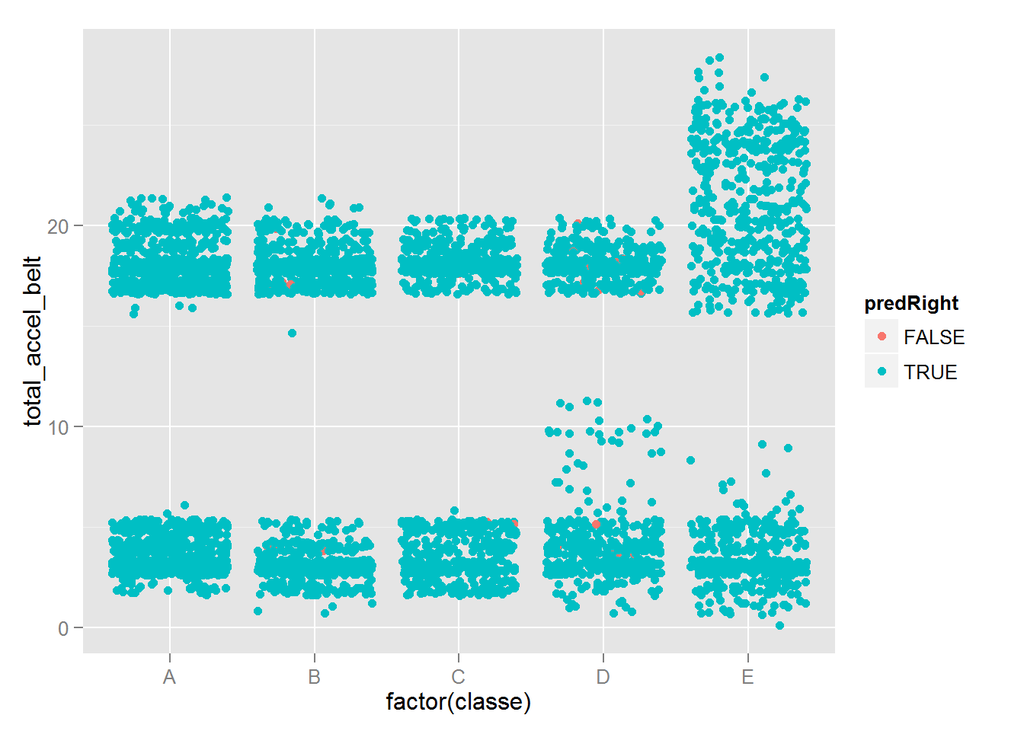

```r
qplot(factor(classe), total_accel_belt, data = testing, colour=predRight, geom=c("jitter"))
```

### Assess the important variables

```r
modFit <- train(classe~ .,
                data=training,
                tuneGrid=data.frame(mtry=3),
                trControl=trainControl(method="none"),
                method="rf"
                )
varImp_Obj <- varImp(modFit)
varImp_Obj
```

```
## rf variable importance
##
##   only 20 most important variables shown (out of 52)
##
##                      Overall
## roll_belt             100.00
## yaw_belt               77.95
## magnet_dumbbell_z      67.18
## pitch_forearm          60.03
## pitch_belt             59.67
## magnet_dumbbell_y      57.98
## magnet_dumbbell_x      49.06
## roll_forearm           47.32
## accel_belt_z           39.88
## accel_dumbbell_y       39.35
## magnet_belt_z          39.18
## magnet_belt_y          38.18
## roll_dumbbell          37.26
## accel_dumbbell_z       34.68
## roll_arm               32.71
## accel_forearm_x        29.57
## gyros_belt_z           29.20
## total_accel_dumbbell   24.81
## accel_dumbbell_x       24.74
## gyros_dumbbell_y       24.54
```

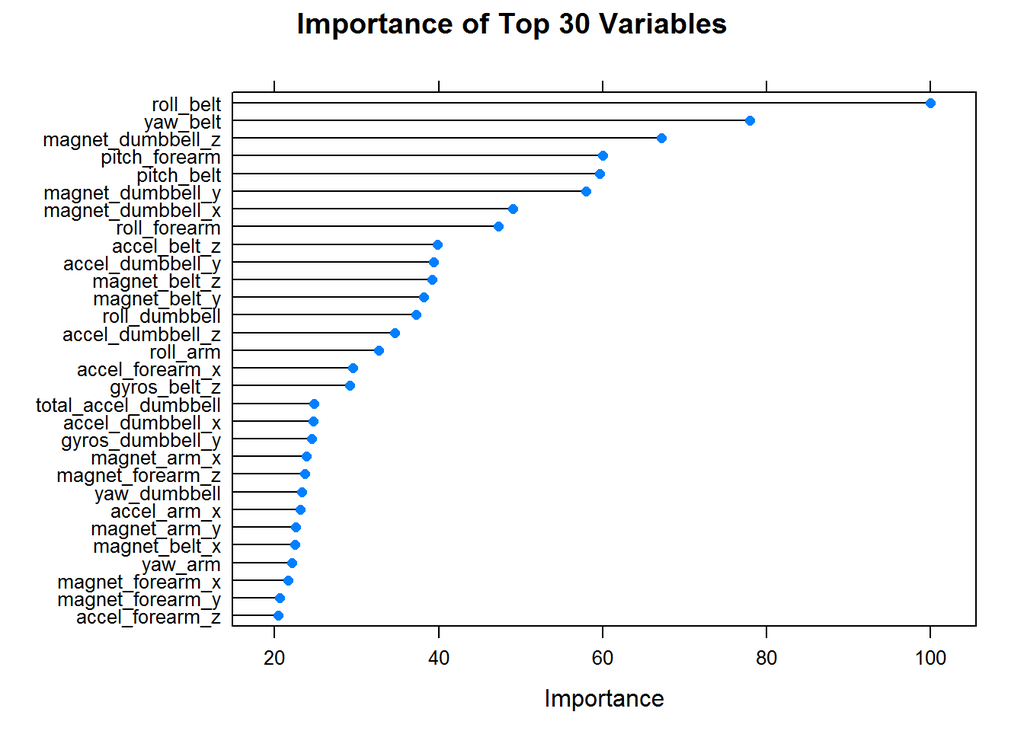

```r
plot(varImp_Obj, main = "Importance of Top 30 Variables", top = 30)
```

### Read unknown testing data, do the same treatment as training data did, and predict it with model to generate 20 answes for 20 questions

```r
testing_new<- read.csv("pml_testing.csv", na.strings=c("NA","#DIV/0!",""))
testing_new <- complete(removeNAcols(testing_new))
answers <- predict(modFit,testing_new)
answers
```

[output not shown]

### write answer for single files for submit

```r
pml_write_files = function(x){
  n = length(x)
  for(i in 1:n){
    filename = paste0("problem_id_",i,".txt")
    write.table(x[i],file=filename,quote=FALSE,row.names=FALSE,col.names=FALSE)
  }
}

pml_write_files(answers)
```